Mapping by Corto · Partie maths · Carnet de bord

# Module 0 — Pourquoi on modélise le compte, pas la fréquence

Fondations rafraîchies sur un vrai mot : *« gouvernement »* dans *Le Monde*, 2023–2024 (731 jours). L'enjeu du module : décider si l'on travaille sur le compte entier X<sub>t</sub> ou sur la fréquence f<sub>t</sub> — et comprendre le *pourquoi*.

## Les données, avant toute formule

Trois séries pour le mot « gouvernement ». Le compte brut X<sub>t</sub> en haut, le volume total de mots du jour N<sub>t</sub> au milieu, la fréquence f<sub>t</sub> = X<sub>t</sub>/N<sub>t</sub> en bas.

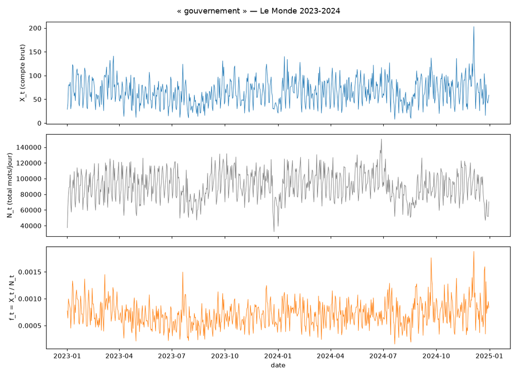

Le compte brut (haut) suit le volume du jour (milieu) — corrélation **0,65**. Les dents de scie de N<sub>t</sub> sont les week-ends. Une fois divisé par le volume, f<sub>t</sub> (bas) est bien plus plat.

L'idée

Chaque jour, on tire un « sac » de N<sub>t</sub> mots. Le nombre de « gouvernement » dépend de **deux choses** : la taille du sac N<sub>t</sub> (un parasite, le volume du jour) et la vraie intensité éditoriale du sujet (ce qu'on veut mesurer — ce qui bouge lors d'un rachat). Il faut neutraliser le premier pour voir le second.

## Un modèle de tirage : la binomiale

Chaque mot du sac est « gouvernement » avec probabilité λ (ici minuscule, ≈ 0,0007). Sur N<sub>t</sub> tirages indépendants, le compte suit une loi **binomiale** X<sub>t</sub> ∼ ℬ(N<sub>t</sub>, λ). Deux faits :

Espérance : 𝔼[X<sub>t</sub>] = N<sub>t</sub> λ

Variance : Var(X<sub>t</sub>) = N<sub>t</sub> λ(1 − λ)

Comme λ est minuscule, 1 − λ ≈ 1, donc :

Var(X<sub>t</sub>) ≈ N<sub>t</sub> λ = 𝔼[X<sub>t</sub>]

La variance égale la moyenne — la signature de la loi de **Poisson** (module 1).

## Pourquoi f<sub>t</sub> est un piège

Le volume N<sub>t</sub> est au **dénominateur** : plus le jour est gros, plus f<sub>t</sub> est fiable.

Autrement dit, deux jours affichant la même fréquence n'ont **pas la même fiabilité**. Un point à f<sub>t</sub> = 0,001 sur 140 000 mots vaut bien plus qu'un point identique sur 20 000 mots — mais sur le graphe de f<sub>t</sub>, ils sont dessinés pareil. L'info de fiabilité est *effacée*.

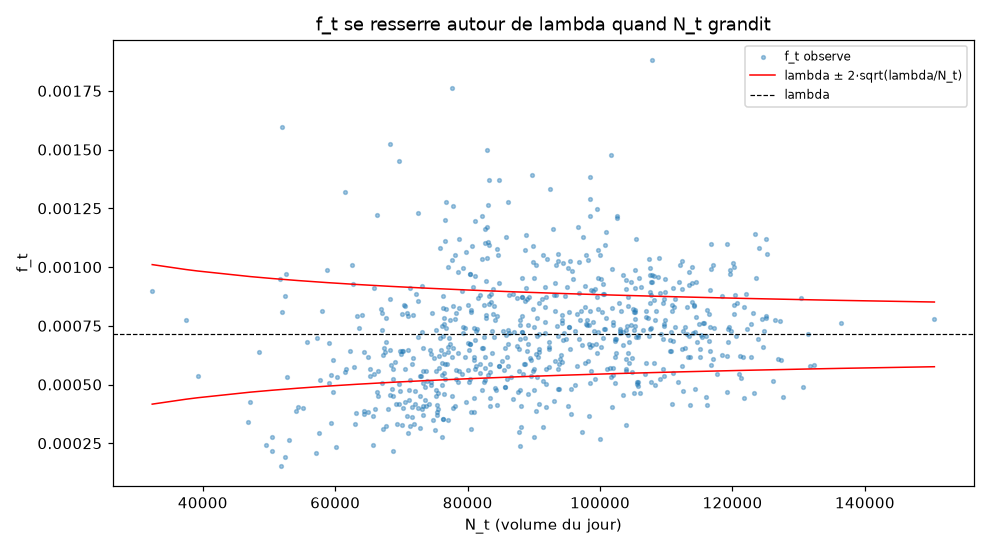

## À retenir

- **On modélise le compte X<sub>t</sub>, pas la fréquence f<sub>t</sub>**, parce que le compte porte en lui la taille de l'échantillon N<sub>t</sub> — donc la fiabilité, qui change chaque jour.
- On injectera N<sub>t</sub> dans le modèle (X<sub>t</sub> ∼ Poisson(λ N<sub>t</sub>)) : le modèle « sait » alors qu'un gros N<sub>t</sub> resserre l'incertitude. C'est ce qui distingue un *vrai* pic d'un petit jour bruyant.
- Indice déjà repéré : moyenne de X<sub>t</sub> = **65,6**, variance = **731,7**. Poisson prédit qu'elles soient égales. Cet écart, la **surdispersion**, est le sujet du module 2 — un vrai signal, pas un défaut.